# Probabilidad e Inferencia Estadística

Jeisson Rodriguez Rodriguez

2024-09-15

A continuación se presentan un problema de probabilidad e inferencia estadística, El problema tiene que ver con una estimación de probabilidad del número pi.

## PROBLEMA 1 - ESTIMACIÓN DEL VALOR DE PI

La siguiente figura sugiere como estimar el valor de $\pi$ con una simulación. En la figura, un círculo con un área igual a $\pi/4$ está inscrito en un cuadrado cuya área es igual a 1. Se elige de forma aleatoria *n* puntos dentro del cuadrado. La probabilidad de que un punto esté dentro del círculo es igual a la fracción del área del cuadrado que abarca a éste, la cual es $\pi/4$. Por tanto, se puede estimar el valor de $\pi/4$ al contar el número de puntos dentro del círculo, para obtener la estimación de $\pi/4$. De este último resultado se encontrar una aproximación para el valor de $\pi$.

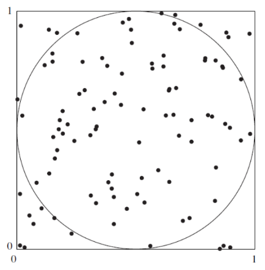

## SOLUCIÓN

como primer paso se generó 1000 puntos tanto para la variable *x* como para la variable *y* con una distribución uniforme de valor mínimo 0 y máximo de 1.

```r
x<-runif(1000, min = 0, max = 1)
y<-runif(1000, min = 0, max = 1)
```

Después, se determinó la distancia de cada uno de los puntos cartesianos

```r
Dist <- ((x-0.5)^2) +((y-0.5)^2)
```

con esto, se asignan los puntos que están dentro del circulo, es decir cumple que sea menor o igual a *0.25*

```r
Puntos <- Dist[Dist <= 0.25]
```

**la cantidad de puntos que cumplen la condición son:**

```r
PuntosCirculo <- length(Puntos)
print(PuntosCirculo)
```

```
## [1] 786
```

**y la estimación del número $\pi$ es:**

```r
EstimacionPi <- ((PuntosCirculo)/1000)*4

print(EstimacionPi)
```

```
## [1] 3.144
```

La diferencia entre el verdadero valor de $\pi$ y la estimación es:

```r
Error <- abs(pi - EstimacionPi)

print(Error)
```

```
## [1] 0.002407346
```

Ahora, generalizamos el código para ingresar la cantidad de puntos deseada.

```r
valorPi <- function(n){

  x<-runif(n, min = 0, max = 1)
  y<-runif(n, min = 0, max = 1)

  Dist <- ((x-0.5)^2) +((y-0.5)^2)

  Puntos <- Dist[Dist <= 0.25]

  PuntosCirculo <- length(Puntos)

  EstimacionPi <- ((PuntosCirculo)/n)*4

  Error <- abs(pi - EstimacionPi)

  sprintf("El valor estimado de π es %s y el error es %s",EstimacionPi,Error)

}
```

Ejecutamos el código ingresando los valores de 10000 y 100000 puntos, esto es:

```r
valorPi(10000)
```

```
## [1] "El valor estimado de π es 3.1336 y el error es 0.00799265358979317"
```

```r
valorPi(100000)
```

```
## [1] "El valor estimado de π es 3.14584 y el error es 0.00424734641020708"
```